```python
import numpy as np
import pandas as pd
import matplotlib.pyplot as plt
```

# PS 03

David Gao

## 1 Explore Distributions

#### 1.1 Basic Properties

#### 1.1.1

```python
# choose S = 10000 for size.
ln_test = np.random.lognormal(0, 1, size=10000)
```

#### 1.1.2

```python
ln_1 = np.random.lognormal(0, 0.2, size=10000)
ln_2 = np.random.lognormal(0, 0.5, size=10000)
ln_3 = np.random.lognormal(0, 1.60, size=10000)
```

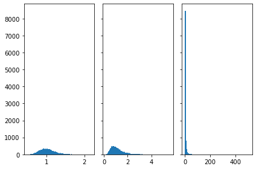

```python
figm, axs = plt.subplots(1, 3, sharey=True, tight_layout=True)
hist_1 = axs[0].hist(ln_1, bins = 100);
hist_2 = axs[1].hist(ln_2, bins = 100);
hist_3 = axs[2].hist(ln_3, bins = 100);
```

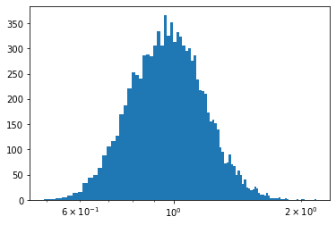

```python
# x in log scale graph
# graph for 1st set of LN data with x axis in log scale
plt.xscale('log')
plt.hist(ln_1, bins = 100)
plt.show()
```

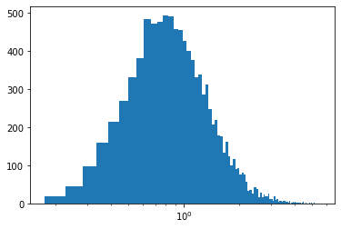

```python
# graph for 2nd set of LN data with x axis in log scale
plt.xscale('log')
plt.hist(ln_2, bins = 100)
plt.show()
```

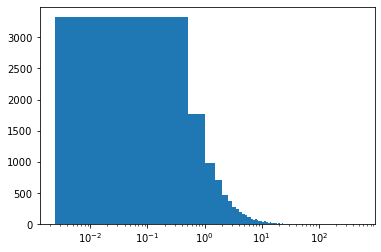

```python
# graph for 3rd set of LN data with x axis in log scale
plt.xscale('log')
plt.hist(ln_3,bins = 1000)
plt.show()
```

All three graphs looks more of standard form of normal distributions, but the third graph is still kind of right skewed.\ \ Reference: \ [histograms plot](https://www.w3schools.com/python/matplotlib_histograms.asp)\ [multiple histograms plot](https://matplotlib.org/stable/gallery/statistics/hist.html)\ [x axis log scale](https://stackoverflow.com/questions/41000668/log-x-axis-for-histogram)

#### 1.1.4

```python
mean1 = ln_1.mean()
mean2 = ln_2.mean()
mean3 = ln_3.mean()
print("The means for three samples are", mean1, ",", mean2,", and", mean3, "correspondingly.")
```

```
The means for three samples are 1.0233073363686742 , 1.142111740203167 , and 3.670368895671078 correspondingly.
```

```python
var1 = ln_1.var()
var2 = ln_2.var()
var3 = ln_3.var()
print("The variances for three samples are", var1, ",", var2,", and", var3, "correspondingly.")
```

```
The variances for three samples are 0.042763284256849145 , 0.3766643599184934 , and 140.07377311327758 correspondingly.
```

```python
# function for mean value
def mean_v( mu, sigma ):
    mean = np.exp(mu + (1/2)*(sigma**2))
    return mean

print("The means for three samples are", mean_v(0, 0.2), ",", mean_v(0, 0.5),", and", mean_v(0, 1.68), "correspondingly.")
```

```
The means for three samples are 1.0202013400267558 , 1.1331484530668263 , and 4.1008735008239405 correspondingly.
```

```python
# function for variance value
def var_v( mu, sigma ):
    var = np.exp(2*mu + sigma**2)*(np.exp(sigma**2) - 1)
    return var

print("The variances for three samples are", var_v(0, 0.2), ",", var_v(0, 0.5),", and", var_v(0, 1.68), "correspondingly.")
```

```
The variances for three samples are 0.04247629348257031 , 0.3646958540123865 , and 265.99982369887033 correspondingly.
```

The values for theoretical and sample means are closer, but variances are kind of different. For the first two sample, which are closer to standard normal distribution, both theoretical and sample values are colser. For the third sample, which is more right skewed, theoretical and sample values are quite different from each other.

#### 1.2 80-20 ratio

#### 1.2.1

#### (a)

```python
total1 = ln_1.sum()
total2 = ln_2.sum()
total3 = ln_3.sum()
print("The sums for three LN samples are", total1, ",", total2, ", and", total3, ".")
```

```
The sums for three LN samples are 10233.073363686743 , 11421.11740203167 , and 36703.68895671078 .
```

#### (b)

```python
threshold1 = np.percentile(ln_1, 90)
threshold2 = np.percentile(ln_2, 90)
threshold3 = np.percentile(ln_3, 90)
print("The corresponding income threshold of three LN samples are", quantile1, ",", quantile2, ", and", quantile3, "correspondingly.")
```

```
The corresponding income threshold of three LN samples are 1.2911813882883998 , 1.9142549101336805 , and 7.922026885490794 correspondingly.
```

#### (c)

```python
top10_1 = ln_1[ln_1 > threshold1].sum()
top10_2 = ln_2[ln_2 > threshold2].sum()
top10_3 = ln_3[ln_3 > threshold3].sum()
print("The total incomes of the top 10 pct for each LN sample are", top10_1, ",", top10_2, ", and", top10_3, ".")
```

```
The total incomes of the top 10 pct for each LN sample are 1430.1319591291572 , 2500.747341949419 , and 23247.21173859522 .
```

#### (d)

```python
share1 = top10_1/total1
share2 = top10_2/total2
share3 = top10_3/total3
print("The wealth share of three samples are", share1, ",", share2, ", and", share3, ".")
```

```
The wealth share of three samples are 0.13975585909548421 , 0.2189582029429597 , and 0.6333753472576978 .
```

None of these are more than 90%.

```python
# repeat for top 20%
quantile1 = np.percentile(ln_1, 89)
quantile2 = np.percentile(ln_2, 89)
quantile3 = np.percentile(ln_3, 89)

top10_1 = ln_1[ln_1 > quantile1].sum()
top10_2 = ln_2[ln_2 > quantile2].sum()
top10_3 = ln_3[ln_3 > quantile3].sum()

share1 = top10_1/total1
share2 = top10_2/total2
share3 = top10_3/total3
print("The wealth share of three samples are", share1, ",", share2, ", and", share3, ".")
```

```
The wealth share of three samples are 0.1522327015959267 , 0.23628261838305395 , and 0.6467570536930668 .
```

Repeat previous calculation for top 11 percent, and still none of these samples are higher than 90%.

#### (e)

```python
def share8020(ln):
    i = 1
    share = 0
    while(~(99<= share + i <= 100)):
        i = i + 1
        threshold = np.percentile(ln, 100 - i)
        top = ln[ln > threshold].sum()
        share = np.ceil((top/ln.sum())*100)
        # print("i:", i, "; share:", share)
    return i, share

top1,share1 = share90(ln_1)
top2,share2 = share90(ln_2)
top3,share3 = share90(ln_3)
print(" Top", top1, "% have ", share1, "% of 'income' in sample1. \n",
     "Top", top2, "% have ", share2, "% of 'income' in sample2. \n",
     "Top", top3, "% have ", share3, "% of 'income' in sample3. \n"
     )
```

```
 Top 46 % have  54.0 % of 'income' in sample1.
 Top 40 % have  60.0 % of 'income' in sample2.
 Top 20 % have  79.0 % of 'income' in sample3.
```

Reference: [round decimals](https://www.delftstack.com/howto/python/python-round-up/#:~:text=Another%20method%20to%20round%20up%20a%20number%20is,integers%2C%20the%20output%20will%20be%20in%20the%20float.)

#### 1.3 Inequality in data

#### 1.3.1

```python
treatment = pd.read_csv(r'treatment.csv', sep='\t')
treatment.head(5)
```

|  | treat | age | educ | ethn | married | re74 | re75 | re78 | u74 | u75 |
| --- | --- | --- | --- | --- | --- | --- | --- | --- | --- | --- |
| 0 | True | 37 | 11 | black | True | 0.0 | 0.0 | 9930.05 | True | True |
| 1 | True | 30 | 12 | black | False | 0.0 | 0.0 | 24909.50 | True | True |
| 2 | True | 27 | 11 | black | False | 0.0 | 0.0 | 7506.15 | True | True |
| 3 | True | 33 | 8 | black | False | 0.0 | 0.0 | 289.79 | True | True |
| 4 | True | 22 | 9 | black | False | 0.0 | 0.0 | 4056.49 | True | True |

```python
mag = pd.read_csv(r'mag-30k-citations.csv', sep='\t')
mag.head(5)
```

|  | id | citations | year |
| --- | --- | --- | --- |
| 0 | 1926704088 | 10 | 2004 |
| 1 | 1590836146 | 0 | 1971 |
| 2 | 2035484488 | 3 | 2007 |
| 3 | 1965723909 | 0 | 2009 |
| 4 | 2021155615 | 42 | 1998 |

Both data looks reasonable.

#### 1.3.2

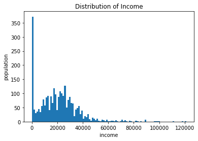

```python
# income plot
plt.hist(treatment.re78, bins = 100)
plt.xlabel("income")
plt.ylabel("population")
plt.title("Distribution of Income")
plt.show()
```

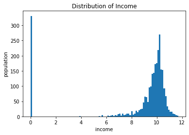

```python
# income log plot
plt.hist(np.log(treatment.re78 + 1), bins = 100)
plt.xlabel("income")
plt.ylabel("population")
plt.title("Distribution of Income")
plt.show()
```

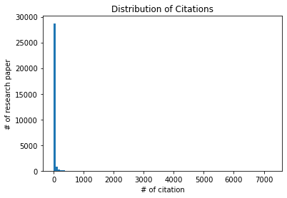

```python
# citation plot
plt.hist(mag.citations, bins = 100)
plt.xlabel("# of citation")
plt.ylabel("# of research paper")
plt.title("Distribution of Citations")
plt.show()
```

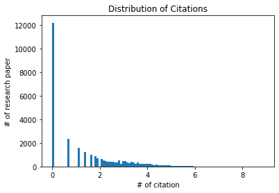

```python
# citation log plot
plt.hist(np.log(mag.citations + 1), bins = 100)
plt.xlabel("# of citation")
plt.ylabel("# of research paper")
plt.title("Distribution of Citations")
plt.show()
```

#### 1.3.3

```python
income_mean = treatment.re78.mean()
income_sd = np.sqrt(treatment.re78.var())
citation_mean = mag.citations.mean()
citation_sd = np.sqrt(mag.citations.var())
print(" The mean and standard deviation of income are", income_mean, "and", income_sd, ". And the mean is", income_mean - income_sd, "larger than standard deviation.", "\n",
     "The mean and standard deviation of citations are", citation_mean, "and", citation_sd, ". And the standard deviation is", citation_sd - citation_mean, "larger than mean.")
```

```
 The mean and standard deviation of income are 20502.37607865417 and 15632.519774212507 . And the mean is 4869.856304441664 larger than standard deviation.
 The mean and standard deviation of citations are 15.605633333333333 and 79.17810312200979 . And the standard deviation is 63.57246978867646 larger than mean.
```

#### 1.3.4

```python
top1,share1 = share8020(treatment.re78)
top2,share2 = share8020(mag.citations)
print(" Top", top1, "% of people have:", share1, "% of income. \n",
     "Top", top2, "% of research papers have", share2, "of citations. \n")
```

```
 Top 36 % of people have: 64.0 % of income.
 Top 17 % of research papers have 83.0 of citations.
```

## 2 Explore Central Limit Theorem

#### 2.1

Expected value is $E(X) = 0.5 \times 1 + 0.5 \times (-1) = 0$. And the variance is $Var(X) = (0.5 \times 1^2 + 0.5 \times (-1)^2) - 0 = 1$.

#### 2.2

Choose R = 1000.

#### 2.3

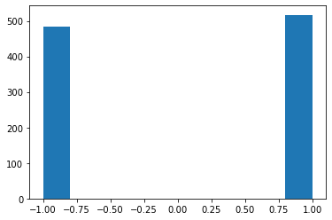

```python
samples = []
for i in range(1000):
    sample = np.random.randint(0,2, size=1)*2 - 1
    samples.append(sample[0])

plt.hist(samples)
plt.show()
```

#### 2.4

```python
mean = np.mean(samples)
var = np.var(samples)
print(" The mean is", mean, "and the variance is", var, ". \n And both value are close to the value calculated in 2.1.")
```

[output not shown]

#### 2.5

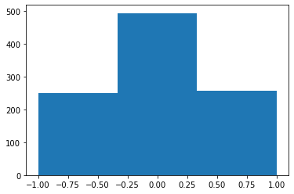

```python
samples2 = []
mean2 = []
for i in range(1000):
    sample = np.random.randint(0,2, size=2)*2 - 1
    mean2.append(sample.mean())
    samples2.append(sample)

plt.hist(mean2, bins = 3)
plt.show()
```

The histogram looks like a normal distribution.

#### 2.6

```python
mean_of_m2 = np.mean(mean2)
var_of_m2 = np.var(mean2)
print("The pair mean is", mean_of_m2, "and the pair variance is", var_of_m2, ".")
```

```
The pair mean is 0.007 and the pair variance is 0.5069509999999999 .
```

The pair mean is similar to the original mean in 2.1, but the pair variance is 1/2 of the original variance in 2.1.

#### 2.7

```python
np.sum(mean2)/1000
```

```
0.007
```

The expected value should stays the similar as 2.1, which is $$E(\bar{X}) = \frac{1}{N} \times \sum_{i}X_i = 0.007$$.

```python
np.mean([i**2 for i in mean2]) - np.sum(mean2)/1000
```

```
0.5
```

The vriance value should be 1/2 of the original variance, $$Var(\bar{X}) = E(\bar{X})^2 - E(\bar{X}^2) = 0.5$$

#### 2.8

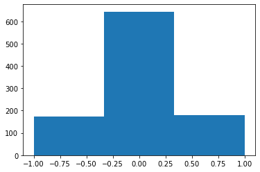

```python
samples5 = []
mean5 = []
for i in range(1000):
    sample = np.random.randint(0,2, size=5)*2 - 1
    mean5.append(sample.mean())
    samples5.append(sample)

plt.hist(mean5, bins = 3)
plt.show()
```

The mean values of samples of 5 are more concentrated to 0, compared with sample of 2.

```python
np.sum(mean5)/1000
```

```
0.0028
```

The expected value should stays the similar as 2.1, which is $$E(\bar{X}) = \frac{1}{N} \times \sum_{i}X_i = 0.0028$$.

```python
np.mean([i**2 for i in mean5]) - np.sum(mean5)/1000
```

```
0.20104
```

The vriance value should be 1/5 of the original variance, $$Var(\bar{X}) = E(\bar{X})^2 - E(\bar{X}^2) = 0.20104$$

#### 2.9

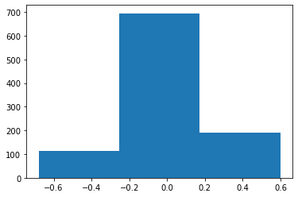

```python
samples25 = []
mean25 = []
for i in range(1000):
    sample = np.random.randint(0,2, size=25)*2 - 1
    mean25.append(sample.mean())
    samples25.append(sample)

plt.hist(mean25, bins = 3)
plt.show()
```

```python
np.sum(mean25)/1000
```

```
-0.005440000000000001
```

The expected value should stays the similar as 2.1, which is $$E(\bar{X}) = \frac{1}{N} \times \sum_{i}X_i = -0.00544$$.

```python
np.mean([i**2 for i in mean25]) - np.sum(mean25)/1000
```

```
0.04288000000000001
```

The vriance value should be 1/25 of the original variance, $$Var(\bar{X}) = E(\bar{X})^2 - E(\bar{X}^2) = 0.04288$$

#### 2.10

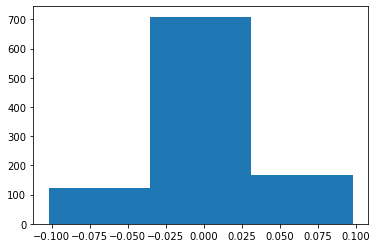

```python
samples1000 = []
mean1000 = []
for i in range(1000):
    sample = np.random.randint(0,2, size=1000)*2 - 1
    mean1000.append(sample.mean())
    samples1000.append(sample)

plt.hist(mean1000, bins = 3)
plt.show()
```

```python
np.sum(mean1000)/1000
```

```
-0.00019399999999999978
```

The expected value should stays the similar as 2.1, which is $$E(\bar{X}) = \frac{1}{N} \times \sum_{i}X_i = -0.00019$$.

```python
np.mean([i**2 for i in mean1000]) - np.sum(mean1000)/1000
```

```
0.0011849239999999997
```

The vriance value should be 1/1000 of the original variance, $$Var(\bar{X}) = E(\bar{X})^2 - E(\bar{X}^2) = 0.00118$$

#### 2.11

As the tuple size increses, the shape of histogram become more concentraded, specifically more mean values repetitions concentraed to 0.

#### 2.12

for each sample, the theoretical expected value is 0 as calculated in 2.1. Thus, as the sample size increases from 1 to 1000, more samples in each repetitions would have mean value to be 0, which is the theoretical expected value. Thus, as number of repetition grows, more samples will have expected value equal to 0, making histograph more concentrated.

I spent around 7 hours on this PS.